# Case Study #2: Finacial Report (2015-2017)

Devin Masiak

4/8/2022

## 2015

Total Revenue = 29,036,749

New Customer Revenue = 29,036,749

Existing Customer Growth = NA

Revenue Lost from Attrition = NA

Existing Customer Revenue Current Year = NA

Existing Customer Revenue Prior Year = NA

Total Customers Current Year = 231,294

Total Customers Previous Year = NA

New Customers = 231,294

Lost Customers = NA

## 2016

Total Revenue = 25,730,944

New Customer Revenue = 17,206,367

Existing Customer Growth = 39,044

Revenue Lost from Attrition = 3,344,849

Existing Customer Revenue Current Year = 8,524,577

Existing Customer Revenue Prior Year = 8,485,533

Total Customers Current Year = 204,646

Total Customers Previous Year = 231,294

New Customers = 136,891

Lost Customers = 163,539

## 2017

Total Revenue = 31,417,495

New Customer Revenue = 21,769,213

Existing Customer Growth = 63,857

Revenue Lost from Attrition = -5,622,694

Existing Customer Revenue Current Year = 9,648,282

Existing Customer Revenue Prior Year = 9,584,425

Total Customers Current Year = 249,987

Total Customers Previous Year = 204,646

New Customers = 173,449

Lost Customers = 128,108

## Dataset Plots

An interesting observation about this dataset is that the distribution of net revenue from customers is largely uniform. The only exceptions occur at the extreme ends of the range. I assume this is most likely a result of the data being randomly generated.

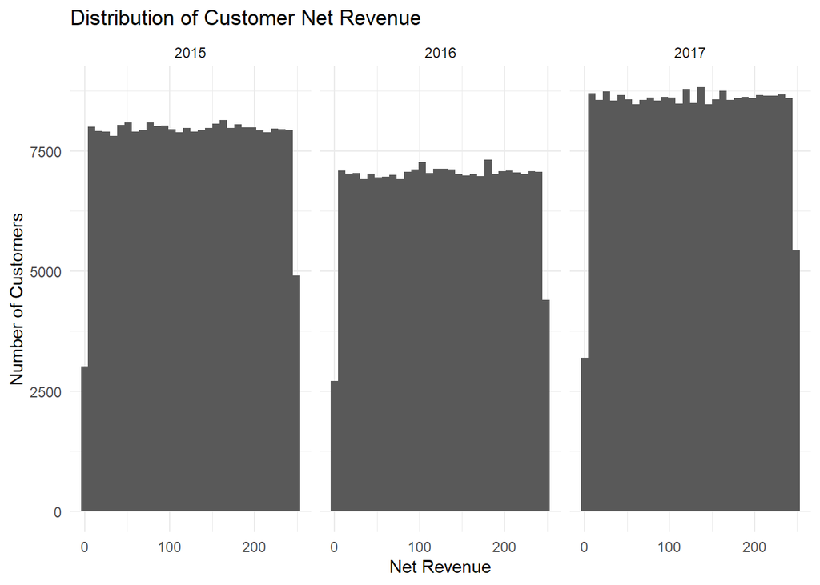

It’s also interesting to look at distribution of how long customers stay with the company. Only ~11% of customers remained all 3 years, while a whopping ~62% only signed up for a single year.

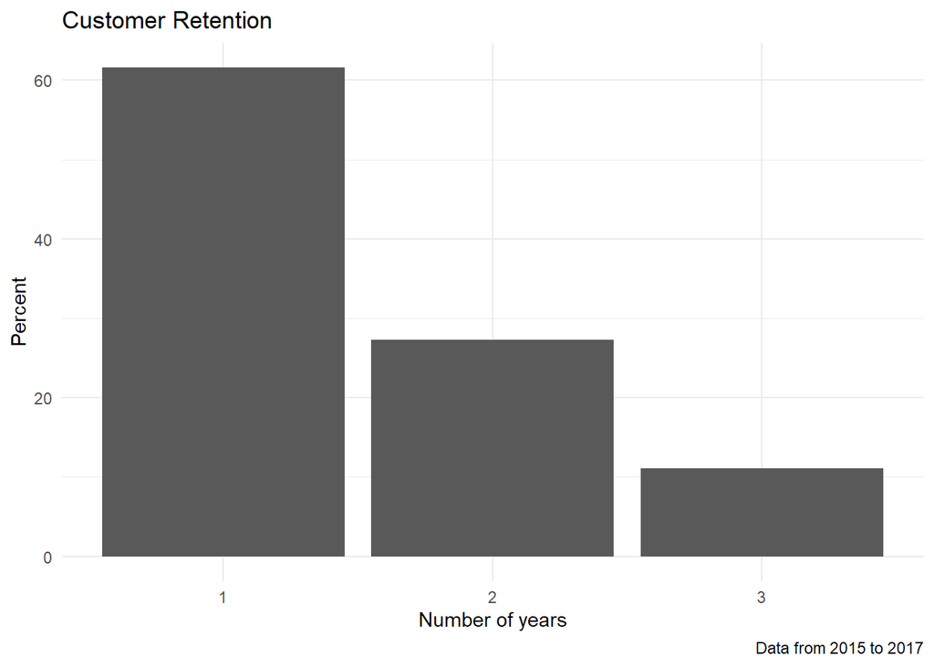